# Tractor Sales Forecast

Amit Kumar

13 January 2018

## Overview of the Framework

**Step 0:** Problem Definition  
**Step 1:** Data Exploration  
**Step 2:** Stationarize the Series  
**Step 3:** Find Optimal Parameters  
**Step 4:** Build ARIMA Model  
**Step 5:** Check for White Noise  
**Step 6:** Investigate Test Error  
**Step 7:** Make Predictions

## Fundamental Idea

The fundamental idea for time series analysis is to decompose the original time series (sales, stock market trends, etc.) into several independent components. Typically, business time series are divided into the following four components:

**Trend** - Overall direction of the series i.e. upwards, downwards etc.  
**Seasonality** - Monthly or quarterly patterns. (e.g. the quarter, month, or day of the week)  
**Cycle** - Long-term business cycles or pattern exists where the data exhibits rises and falls that are not of fixed period (duration usually of at least 2 years)  
**Irregular remainder** - Random noise left after extraction of all the components

### Difference Between Seasonal & Cyclic

**1.** Seasonal pattern constant length vs. cyclic pattern variable length  
**2.** Average length of cycle longer than length of seasonal pattern  
**3.** Magnitude of cycle more variable than magnitude of seasonal pattern.

The timing of peaks and troughs is predictable with seasonal data, but unpredictable in the long term with cyclic data.

## Prerequisites & Basic Setting

```r
# Add list of packages required
list.of.packages <- c("sweep", "forecast", "tidyquant", "timetk", "urca", "sweep", "tseries")
new.packages <- list.of.packages[!(list.of.packages %in% installed.packages()[,"Package"])]
if(length(new.packages)) install.packages(new.packages)


# Set working directory - change as per your current working directory
# setwd("~/Time Series/Sales Forecast")


# Import packages
library(sweep)
library(forecast)
library(tidyquant)
library(urca) # For advance Dickey Full Test
library(timetk)
library(sweep)
library(tseries) # Only use for adf.test
```

## Data Preparation

```r
# Import Data
Sales_Data <- read.csv("Sales Data.csv", stringsAsFactors = F)

# Rename default column name to date and value
Sales_Data <- Sales_Data %>%
  select(Month.Year, Number.of.Tractor.Sold) %>%
  rename(date = Month.Year, value = Number.of.Tractor.Sold)

Sales_Data_TS <- ts(Sales_Data$value, start = c(2003, 1), frequency = 12)
# SALES_Data_Tbl <- tk_tbl(Sales_Data_TS, timetk_idx = FALSE, rename_index = "date")

# convert date column to full date
Sales_Data$date <- as.Date(time(Sales_Data_TS))

# Convert to tibble - just to take benefit of advance feature of timetk package
# More info: http://www.business-science.io/code-tools/2017/10/24/demo_week_timetk.html
Sales_Data <- tk_tbl(data = Sales_Data)

# Check for timetk index
# has_timetk_idx(Sales_Data_TS)

# Convert ts to tk_ts for timetk_idx and take benefit of advance feature of timetk package
Sales_Data_TS <- tk_ts(Sales_Data, start = c(2003, 1), frequency = 12)


# One way of splitting a time series is by using the window() function, which extracts a subset from #the object x observed between the times start and end.

# window(x, start = NULL, end = NULL)


# Splitting data into train and test
# Sales_Data_TS_Train <- window(Sales_Data_TS, end = c(2012,12))
Sales_Data_TS_Train <- tk_ts(Sales_Data[0:120, ], start = c(2003, 1), frequency = 12)
Sales_Data_TS_Test <- tk_ts(Sales_Data[121:144, ], start = c(2013, 1), frequency = 12)
```

## Step 0: Problem Definition

PowerHorse, a tractor and farm equipment manufacturing company, was established a few years after World War II. The company has shown a consistent growth in its revenue from tractor sales since its inception. However, over the years the company has struggled to keep it’s inventory and production cost down because of variability in sales and tractor demand. The management at PowerHorse is under enormous pressure from the shareholders and board to reduce the production cost. Additionally, they are also interested in understanding the impact of their marketing and farmer connect efforts towards overall sales. In the same effort, they have hired you as a data science and predictive analytics consultant.

You will start your investigation of this problem in the next part of this series using the concept discussed in this article. Eventually, you will develop an ARIMA model to forecast sale / demand for next year, to manage their inventories and suppliers.Additionally, you will also investigate the impact of marketing program on sales by using an exogenous variable ARIMA model.

The following sections in this article represent your analysis in the form of a graphic guide.You could find the data at the following link [Tractor Sales Data](http://ucanalytics.com/blogs/wp-content/uploads/2015/06/Tractor-Sales.csv). You may want to analyze this data to revalidate the analysis you will carry-out in the following sections.

## Step 1: Data Exploration

```r
# Review Data
Sales_Data %>%
  tk_index() %>%
  tk_get_timeseries_summary() %>%
  glimpse()
```

```
## Observations: 1
## Variables: 12
## $ n.obs        <int> 144
## $ start        <date> 2003-01-01
## $ end          <date> 2014-12-01
## $ units        <chr> "days"
## $ scale        <chr> "month"
## $ tzone        <chr> "UTC"
## $ diff.minimum <dbl> 2419200
## $ diff.q1      <dbl> 2592000
## $ diff.median  <dbl> 2678400
## $ diff.mean    <dbl> 2629460
## $ diff.q3      <dbl> 2678400
## $ diff.maximum <dbl> 2678400
```

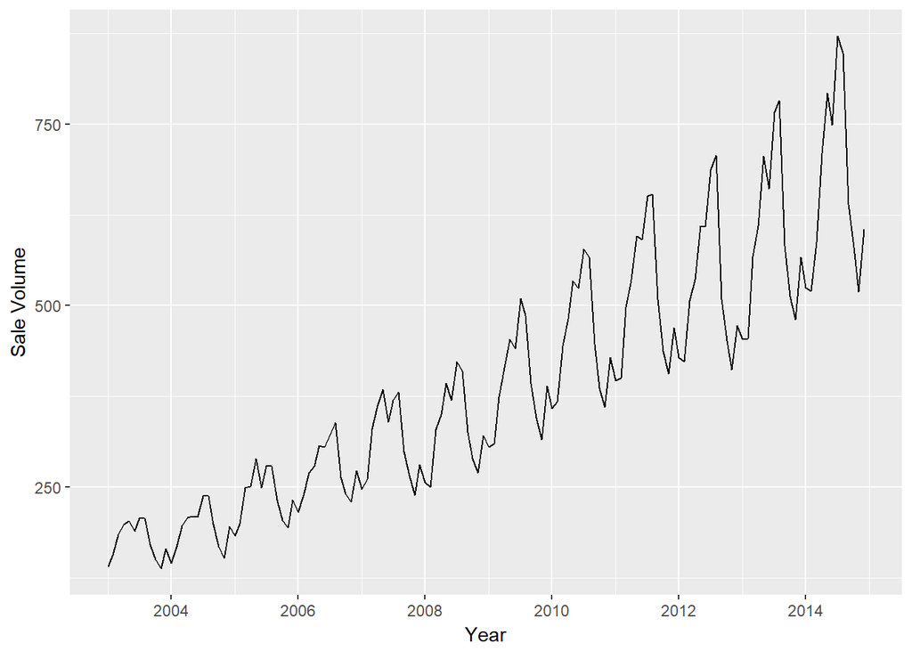

```r
# Simple time plot
autoplot(Sales_Data_TS, xlab = 'Year', ylab='Sale Volume')
```

```r
# Summary
summary(Sales_Data_TS_Train)
```

```
##      value
##  Min.   :138.0
##  1st Qu.:236.5
##  Median :321.5
##  Mean   :341.8
##  3rd Qu.:428.0
##  Max.   :707.0
```

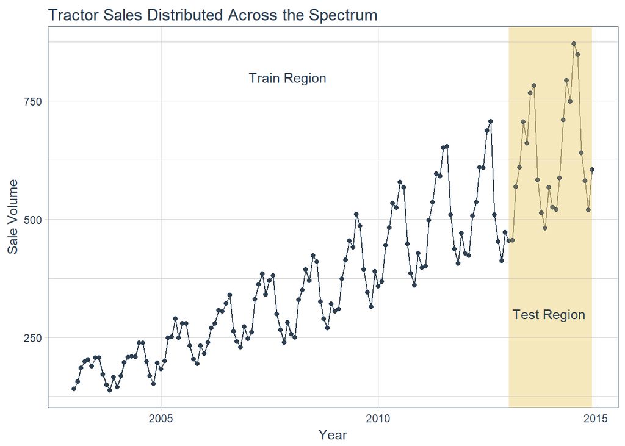

```r
# Data split on train and test
ggplot(data=Sales_Data, aes(x = date, y = value)) +
  geom_line(col = palette_light()[1]) +
  geom_point(col = palette_light()[1]) +
  geom_rect(xmin = as.numeric(ymd("2013-01-01")),
            xmax = as.numeric(ymd("2014-12-01")),
            ymin = 0, ymax = 8000,
            fill = palette_light()[[4]], alpha = 0.01) +
  annotate("text", x = ymd("2007-12-01"), y = 800,
           color = palette_light()[[1]], label = "Train Region") +
  annotate("text", x = ymd("2013-12-01"), y = 300,
           color = palette_light()[[1]], label = "Test Region") +
  geom_point(alpha = 0.5, color = palette_light()[[1]]) +
  labs(
    title = "Tractor Sales Distributed Across the Spectrum",
    x = "Year",
    y="Sale Volume") +
  theme_tq()
```

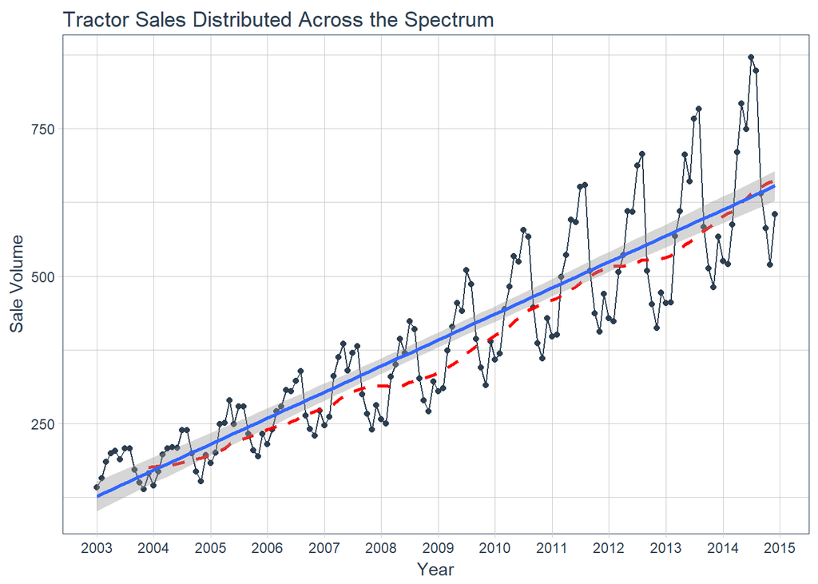

```r
# Volume of tractor sales distributed across the spectrum
Sales_Data %>%
  ggplot(aes(date, value)) +
  geom_line(col = palette_light()[1]) +
  geom_point(col = palette_light()[1]) +
  geom_ma(ma_fun = SMA, n = 12, size = 1, color = "red") +
  geom_smooth(method='lm') +
  theme_tq() +
  scale_x_date(date_breaks = "1 year", date_labels = "%Y") +
  labs(title = "Tractor Sales Distributed Across the Spectrum",
       x = "Year",
       y = "Sale Volume")
```

From the above plot you can find the increasing trend in the data.

Red dotted line shows the moving average is increasing over time.

Blue line shows the best fit line that is based on simple linear regression.

### Some Simple Forecasting Method

Sometimes one of these simple methods will be the best forecasting method available; but in many cases, these methods will serve as benchmarks rather than the method of choice. That is, any forecasting methods we develop will be compared to these simple methods to ensure that the new method is better than these simple alternatives. If not, the new method is not worth considering.

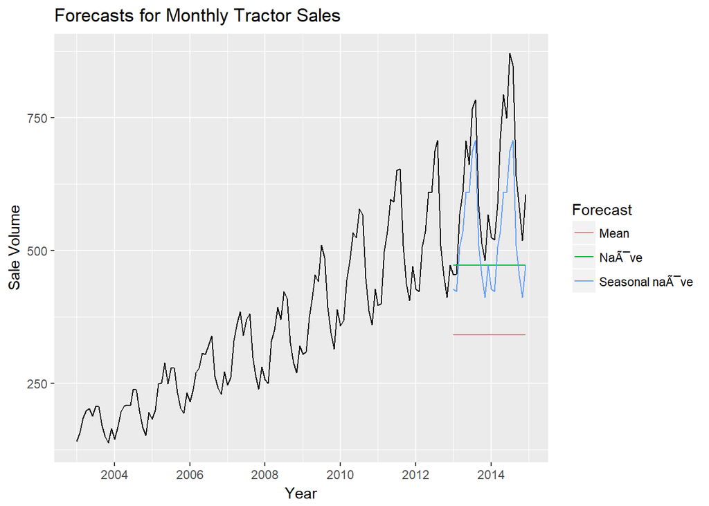

```r
# Plot some forecasts
autoplot(Sales_Data_TS) +
  forecast::autolayer(meanf(Sales_Data_TS_Train, h=24)$mean, series="Mean") +
  forecast::autolayer(naive(Sales_Data_TS_Train, h=24)$mean, series="NaÃ¯ve") +
  forecast::autolayer(snaive(Sales_Data_TS_Train, h=24)$mean, series="Seasonal naÃ¯ve") +
  ggtitle("Forecasts for Monthly Tractor Sales ") +
  xlab("Year") + ylab("Sale Volume") +
  guides(colour=guide_legend(title="Forecast"))
```

```r
# h is the forecast horizon
```

You can check and compare the above simple forecasts with actual data before moving to the more advanced ARIMA model. We can use it as a baseline in our analysis.

### Seasonal plots

Along with time plots, there are other useful ways of plotting data to emphasize seasonal patterns and show changes in these patterns over time.

A **seasonal plot** is similar to a time plot except that the data are plotted against the individual “seasons” in which the data were observed. You can create one using the **ggseasonplot()** function the same way you do with autoplot().

An interesting variant of a season plot uses polar coordinates, where the time axis is circular rather than horizontal; to make one, simply add a **polar** argument and set it to **TRUE**.

A **subseries plot** comprises mini time plots for each season. Here, the mean for each season is shown as a blue horizontal line.

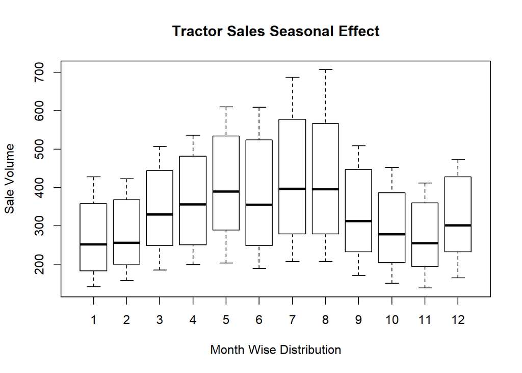

```r
## Cycle across the years
# cycle(Sales_Data_TS_Train)

# Sense of Seasonal effect
boxplot(Sales_Data_TS_Train~cycle(Sales_Data_TS_Train), xlab = c("Month Wise Distribution"), ylab = c("Sale Volume"))
title("Tractor Sales Seasonal Effect")
```

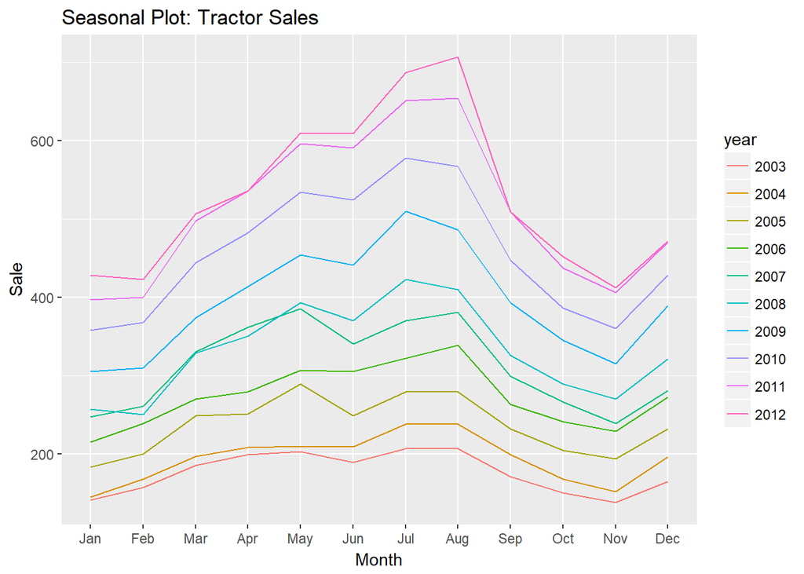

```r
# Some more plots for illustration
# par(mfrow = c(1,3))
ggseasonplot(Sales_Data_TS_Train) +
  ylab("Sale") + ggtitle("Seasonal Plot: Tractor Sales")
```

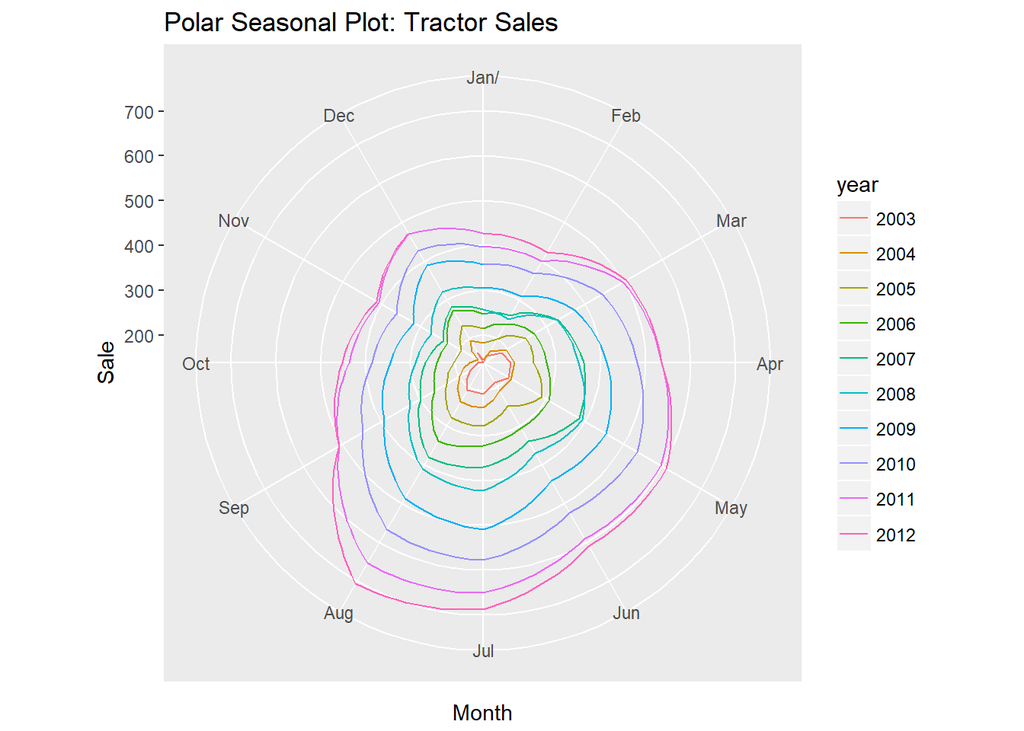

```r
ggseasonplot(Sales_Data_TS_Train, polar = T) +
  ylab("Sale") + ggtitle("Polar Seasonal Plot: Tractor Sales")
```

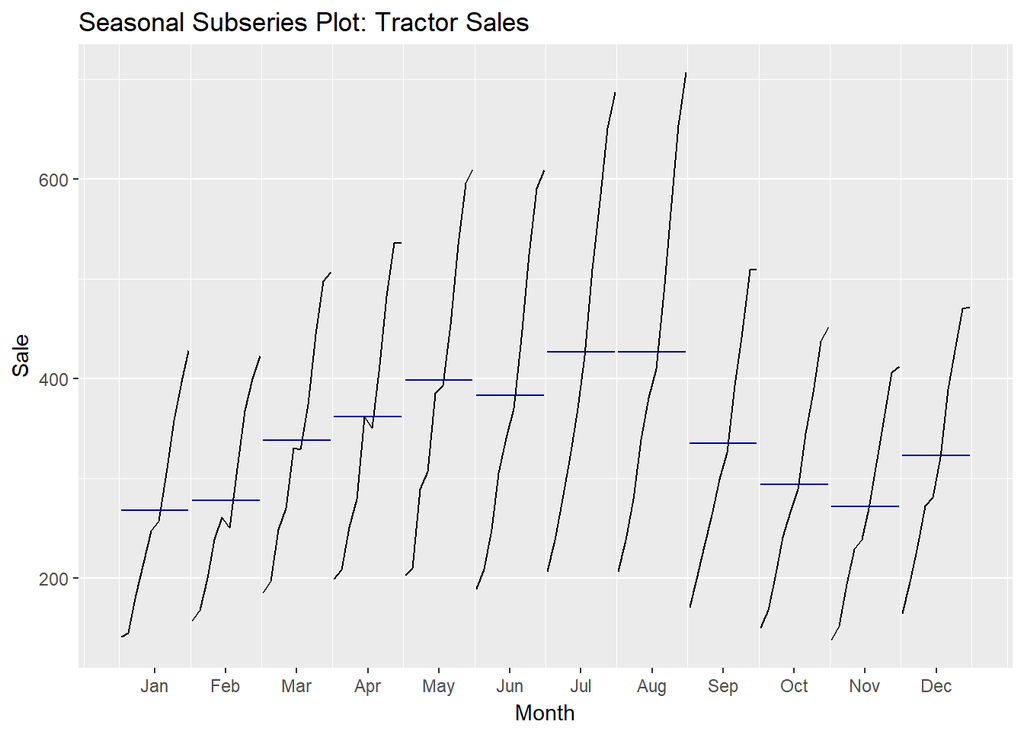

```r
ggsubseriesplot(Sales_Data_TS_Train) +
  ylab("Sale") + ggtitle("Seasonal Subseries Plot: Tractor Sales")
```

It is clear from above illustrations that there are large jumps in sale in the mnths of July, August and December.

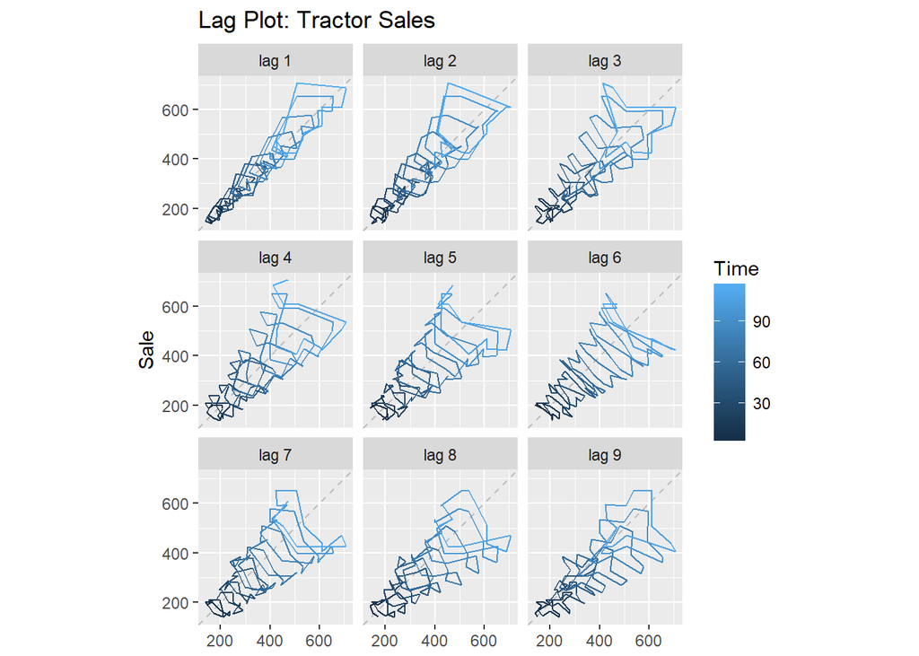

```r
gglagplot(as.numeric(Sales_Data_TS_Train)) +
  ylab("Sale") + ggtitle("Lag Plot: Tractor Sales")
```

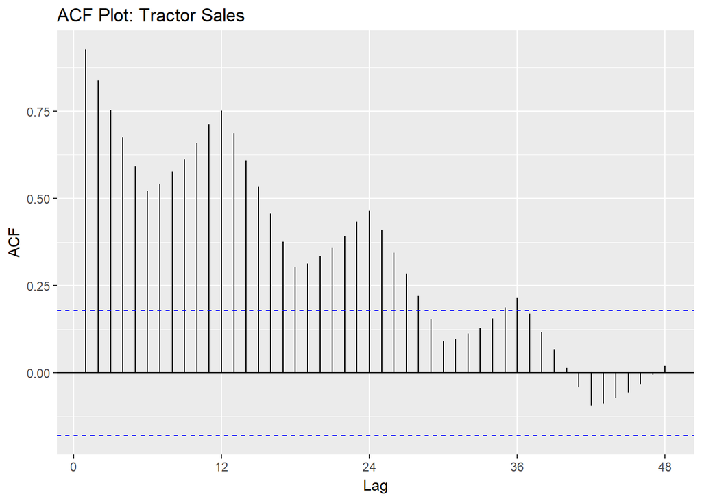

```r
ggAcf(Sales_Data_TS_Train, lag.max = 48) +
  ggtitle("ACF Plot: Tractor Sales")
```

The slow decrease in the ACF as the lags increase is due to the trend, while the scalloped shape is due the seasonality. Again, there peaks above the dotted blue line and this shows the series has information in it and it is not White Noise.

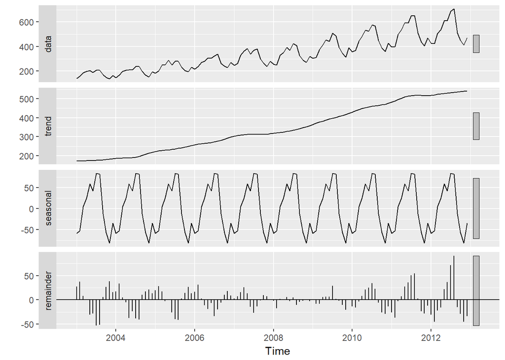

```r
# Full decompose
autoplot(stl(ts(Sales_Data$value[0:120], start = c(2003, 1), frequency = 12), s.window = 'periodic'))
```

## Step 2: Stationarize the Series

We know that we need to address two issues before we test stationary series.  
**1.** We need to remove unequal variances. We do this using log of the series.  
**2.** We need to address the trend component. We do this by taking difference of the series.

Now, let’s test the resultant series.

The test results comprise of a Test Statistic and some Critical Values for difference confidence levels. If the ‘Test Statistic’ is less than the ‘Critical Value’, we can reject the null hypothesis and say that the series is stationary.

```r
# Null hypothesis testing of stationarity
adf.test(Sales_Data_TS_Train, alternative = "stationary", k=0)
```

```
##
##  Augmented Dickey-Fuller Test
##
## data:  Sales_Data_TS_Train
## Dickey-Fuller = -4.1838, Lag order = 0, p-value = 0.01
## alternative hypothesis: stationary
```

```r
adf.test(diff(Sales_Data_TS_Train, 1), alternative = "stationary", k=0)
```

```
##
##  Augmented Dickey-Fuller Test
##
## data:  diff(Sales_Data_TS_Train, 1)
## Dickey-Fuller = -8.9477, Lag order = 0, p-value = 0.01
## alternative hypothesis: stationary
```

We’re not getting expected p-value from adf.test, we’re trying get that with more advance Dickey Fuller test for stationarity from ‘urca’ package.

```r
# Null hypothesis testing of stationarity
summary(ur.df(Sales_Data_TS_Train))
```

```
##
## ###############################################
## # Augmented Dickey-Fuller Test Unit Root Test #
## ###############################################
##
## Test regression none
##
##
## Call:
## lm(formula = z.diff ~ z.lag.1 - 1 + z.diff.lag)
##
## Residuals:
##      Min       1Q   Median       3Q      Max
## -198.426  -19.975    1.671   30.193   99.246
##
## Coefficients:
##             Estimate Std. Error t value Pr(>|t|)
## z.lag.1    -0.004457   0.011863  -0.376   0.7078
## z.diff.lag  0.178852   0.092420   1.935   0.0554 .
## ---
## Signif. codes:  0 '***' 0.001 '**' 0.01 '*' 0.05 '.' 0.1 ' ' 1
##
## Residual standard error: 47.19 on 116 degrees of freedom
## Multiple R-squared:  0.03154,    Adjusted R-squared:  0.01485
## F-statistic: 1.889 on 2 and 116 DF,  p-value: 0.1558
##
##
## Value of test-statistic is: -0.3757
##
## Critical values for test statistics:
##       1pct  5pct 10pct
## tau1 -2.58 -1.95 -1.62
```

```r
summary(ur.df(diff(Sales_Data_TS_Train)))
```

```
##
## ###############################################
## # Augmented Dickey-Fuller Test Unit Root Test #
## ###############################################
##
## Test regression none
##
##
## Call:
## lm(formula = z.diff ~ z.lag.1 - 1 + z.diff.lag)
##
## Residuals:
##      Min       1Q   Median       3Q      Max
## -196.351  -24.474    1.948   29.793   95.302
##
## Coefficients:
##            Estimate Std. Error t value Pr(>|t|)
## z.lag.1    -0.88242    0.11983  -7.364  2.9e-11 ***
## z.diff.lag  0.06898    0.09398   0.734    0.464
## ---
## Signif. codes:  0 '***' 0.001 '**' 0.01 '*' 0.05 '.' 0.1 ' ' 1
##
## Residual standard error: 47.25 on 115 degrees of freedom
## Multiple R-squared:  0.4132, Adjusted R-squared:  0.403
## F-statistic: 40.49 on 2 and 115 DF,  p-value: 4.888e-14
##
##
## Value of test-statistic is: -7.3642
##
## Critical values for test statistics:
##       1pct  5pct 10pct
## tau1 -2.58 -1.95 -1.62
```

Alternatively we can check non-stationarity test as well.

```r
# Null hypothesis testing of non-stationarity
kpss.test(Sales_Data_TS_Train)
```

```
##
##  KPSS Test for Level Stationarity
##
## data:  Sales_Data_TS_Train
## KPSS Level = 3.3904, Truncation lag parameter = 2, p-value = 0.01
```

```r
kpss.test(diff(Sales_Data_TS_Train, 1))
```

```
##
##  KPSS Test for Level Stationarity
##
## data:  diff(Sales_Data_TS_Train, 1)
## KPSS Level = 0.018516, Truncation lag parameter = 2, p-value = 0.1
```

Though the variation in standard deviation is small, rolling mean is clearly increasing with time and this is not a stationary series. Also, the test statistic is way more than the critical values.

From above test we can assume that our time series data is not stationary. Make the series stationary by removing the upward trend through 1st order differencing of the series.

Difference data to make data stationary on mean (remove trend)

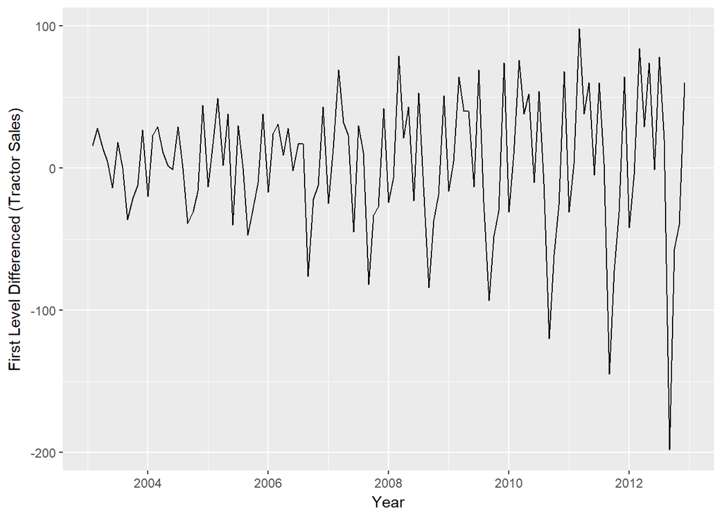

```r
# ndiffs(Sales_Data_TS) - we can use ndiffs as well, but I don't have much knowledge on its accuracy.
autoplot(diff(Sales_Data_TS_Train), xlab = 'Year', ylab='First Level Differenced (Tractor Sales)')
```

Okay so the above series is not stationary on variance i.e. variation in the plot is increasing as we move towards the right of the chart. We need to make the series stationary on variance to produce reliable forecasts through ARIMA models.

### Transformations for Variance Stablization

The purpose of transformations is to simplify the patterns in the historical data by removing known sources of variation or by making the pattern more consistent across the whole data set.

Here we’ve a function **BoxCox.lamda()** from forecast package which will guide us about the mathematical transformation of the time series data. It will return the lambda value **(Î»)** and its range is from **-1>=Î»>=1**.

**Î»=1:** No substantive transformation  
**Î»=1/2:** Square root plus linear trasnformation  
**Î»=1/3:** Cube root plus linear trasnformation  
**Î»=0:** Natural logarithmic transformation  
**Î»=-1:** Inverse transformation

```r
BoxCox.lambda(Sales_Data_TS_Train)
```

```
## [1] -0.2291694
```

```r
# log transform data to make data stationary on variance
Sales_Data_TS_Train_Log <- log10(Sales_Data_TS_Train)
Sales_Data_TS_Test_Log <- log10(Sales_Data_TS_Test)
```

Now check the result after log transformation.

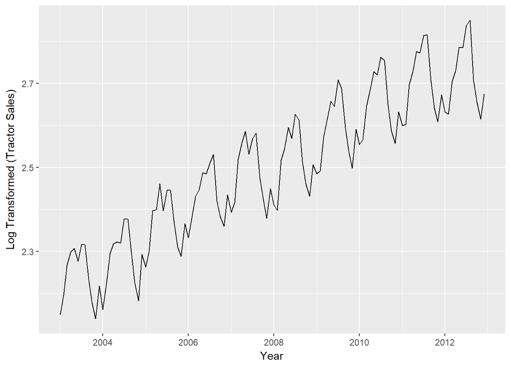

```r
par(mfrow = c(1,2))
autoplot(Sales_Data_TS_Train_Log, xlab = 'Year', ylab='Log Transformed (Tractor Sales)')
```

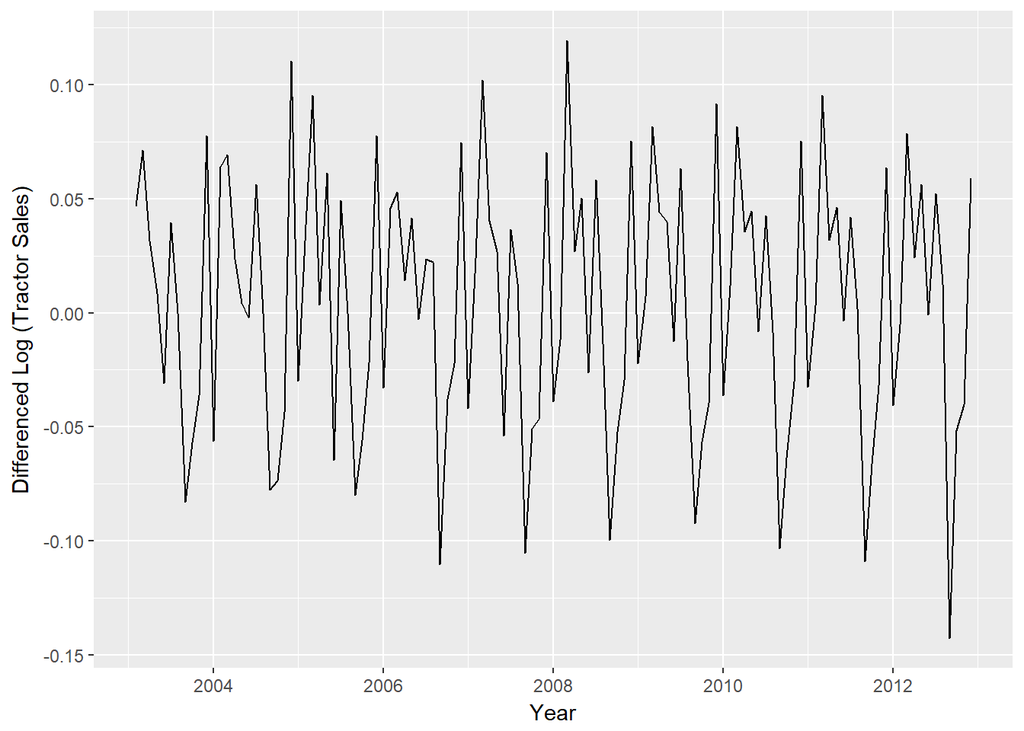

```r
autoplot(diff(Sales_Data_TS_Train_Log), xlab = 'Year', ylab='Differenced Log (Tractor Sales)')
```

Yes, now this series looks stationary on both mean and variance. This also gives us the clue that I or integrated part of our ARIMA model will be equal to 1 as 1st difference is making the series stationary.

## Step 3: Find Optimal Parameters

Now, let us create autocorrelation factor (ACF) and partial autocorrelation factor (PACF) plots to identify patterns in the above data which is stationary on both mean and variance. The idea is to identify presence of AR and MA components in the residuals.

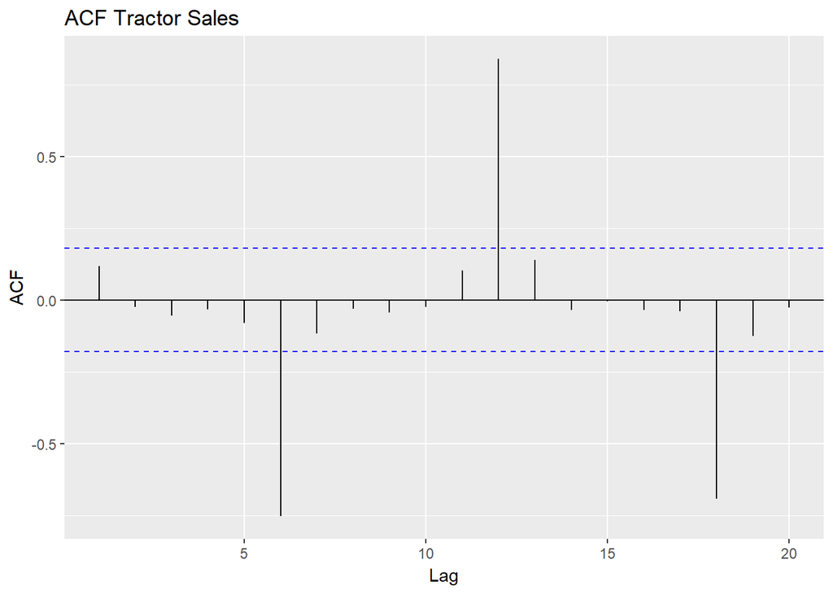

```r
  # ACF Model
  par(mfrow = c(1,2))
  ggAcf(ts(diff(Sales_Data_TS_Train_Log))) + ggtitle("ACF Tractor Sales")
```

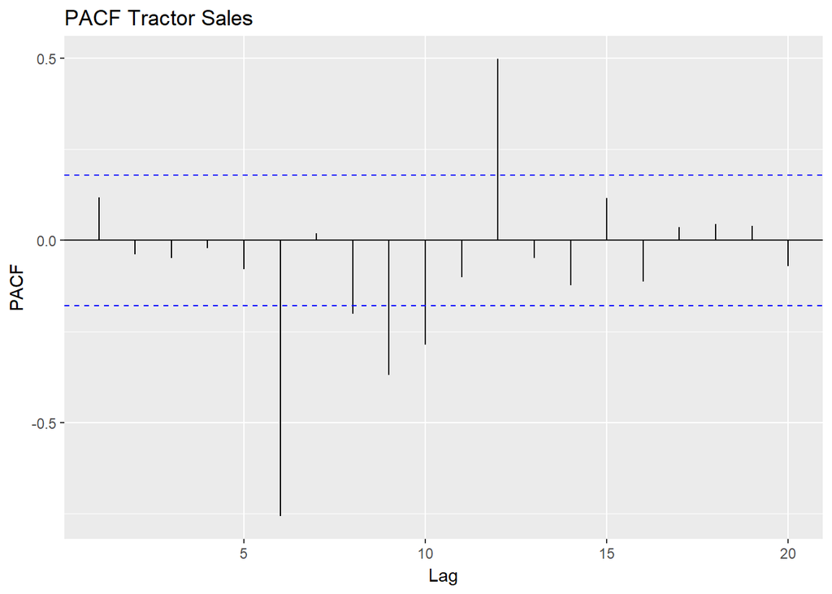

```r
  ggPacf(ts(diff(Sales_Data_TS_Train_Log))) + ggtitle("PACF Tractor Sales")
```

Since, there are enough spikes in the plots outside the insignificant zone (dotted horizontal lines) we can conclude that the residuals are not random. This implies that there is information available in residuals to be extracted by AR and MA models. Also, there is a seasonal component available in the residuals at the lag 12 (represented by spikes at lag 12). This makes sense since we are analyzing monthly data that tends to have seasonality of 12 months because of patterns in tractor sales.

auto.arima function in forecast package in R helps us identify the best fit ARIMA model on the fly.

```r
# ARIMAfit = auto.arima(Sales_Data_TS_Log, approximation=FALSE,trace=FALSE)
summary(auto.arima(Sales_Data_TS_Train_Log, approximation=FALSE,trace=FALSE))
```

```
## Series: Sales_Data_TS_Train_Log
## ARIMA(0,1,1)(0,1,1)[12]
##
## Coefficients:
##           ma1     sma1
##       -0.3471  -0.5355
## s.e.   0.0996   0.0876
##
## sigma^2 estimated as 0.0002688:  log likelihood=287.06
## AIC=-568.12   AICc=-567.89   BIC=-560.11
##
## Training set error measures:
##                         ME       RMSE        MAE          MPE      MAPE
## Training set -6.717869e-05 0.01533676 0.01139577 -0.002628277 0.4559706
##                   MASE        ACF1
## Training set 0.2131231 0.002369706
```

The best fit model is selected based on Akaike Information Criterion (AIC), and Bayesian Information Criterion (BIC) values. The idea is to choose a model with minimum AIC and BIC values.

As expected, our model has I (or integrated) component equal to 1. This represents differencing of order 1. There is additional differencing of lag 12 in the above best fit model. Moreover, the best fit model has MA value of order 1. Also, there is seasonal MA with lag 12 of order 1.

## Step 4: Build ARIMA Model

```r
# ARIMA(0,1,1)(0,1,1)[12]
fit = Arima(Sales_Data_TS_Train_Log, order = c(0, 1, 1), seasonal = list(order = c(0, 1, 1), period = 12))
```

## Step 5: Check for White Noise

Plot ACF and PACF for residuals of ARIMA model to ensure no more information is left for extraction.

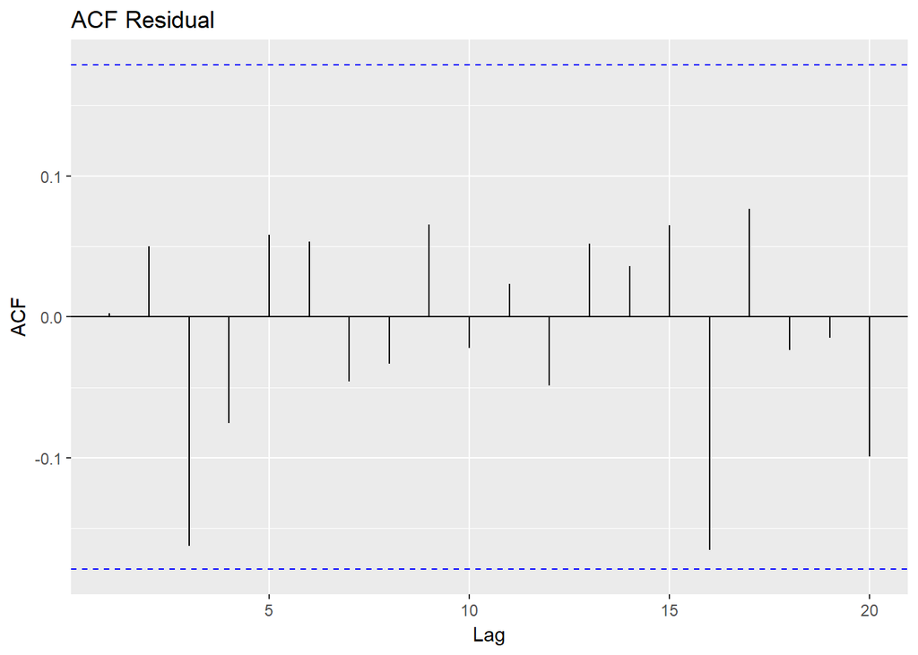

```r
# par(mfrow=c(1,2))
ggAcf(ts(fit$residuals)) + ggtitle("ACF Residual")
```

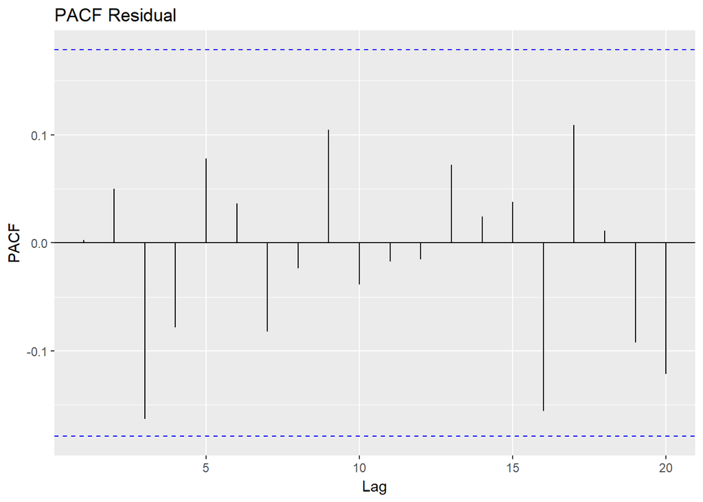

```r
ggPacf(ts(fit$residuals)) + ggtitle("PACF Residual")
```

Inspite of diagnosing residuals separately we can use a **checkresiduals** function to do our task. It uses Ljung-Box test.

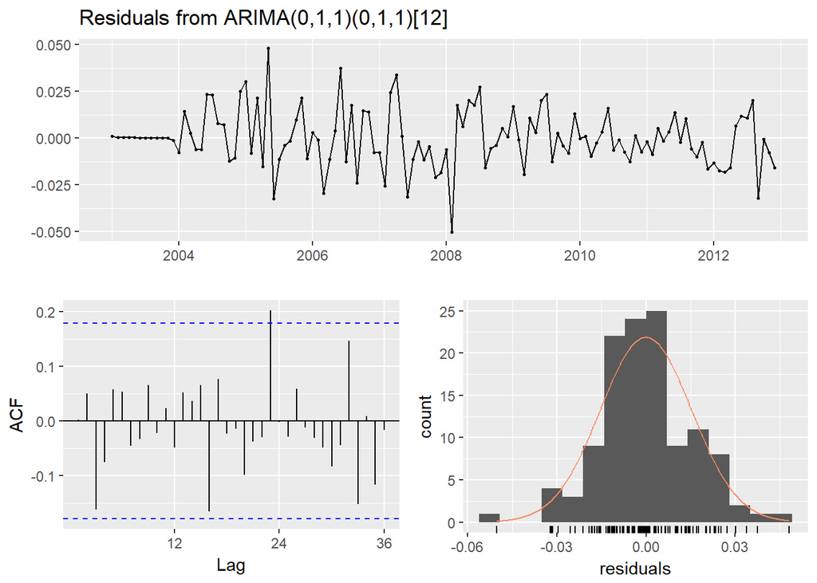

```
##
##  Ljung-Box test
##
## data:  Residuals from ARIMA(0,1,1)(0,1,1)[12]
## Q* = 20.416, df = 22, p-value = 0.557
##
## Model df: 2.   Total lags used: 24
```

```r
# Residual Diagnostics
checkresiduals(fit)
```

### Few Assumptions from Residual Diagnostics

**1.** Here, **p-value > 0.05** threshold in time plot shows that residuals are White Noise  
**2.** More than 95% of values are under blue dotted line in ACF plot shows no information is left in residuals and no problem with autocorrelation  
**3.** Histogram looks pretty close to normal distribution or normal curve

```r
# sw_tidy - Get model coefficients
sw_tidy(fit)
```

```
## # A tibble: 2 x 2
##   term  estimate
##   <chr>    <dbl>
## 1 ma1     -0.347
## 2 sma1    -0.536
```

```r
# sw_glance - Get model description and training set accuracy measures
sw_glance(fit) %>%
  glimpse()
```

```
## Observations: 1
## Variables: 12
## $ model.desc <chr> "ARIMA(0,1,1)(0,1,1)[12]"
## $ sigma      <dbl> 0.01639568
## $ logLik     <dbl> 287.0622
## $ AIC        <dbl> -568.1245
## $ BIC        <dbl> -560.106
## $ ME         <dbl> -6.717869e-05
## $ RMSE       <dbl> 0.01533676
## $ MAE        <dbl> 0.01139577
## $ MPE        <dbl> -0.002628277
## $ MAPE       <dbl> 0.4559706
## $ MASE       <dbl> 0.2131231
## $ ACF1       <dbl> 0.002369706
```

```r
# sw_augment - get model residuals
sw_augment(fit, timetk_idx = TRUE)
```

```
## # A tibble: 120 x 4
##    index      .actual .fitted    .resid
##    <date>       <dbl>   <dbl>     <dbl>
##  1 2003-01-01    2.15    2.15 0.00124
##  2 2003-02-01    2.20    2.20 0.000591
##  3 2003-03-01    2.27    2.27 0.000447
##  4 2003-04-01    2.30    2.30 0.000361
##  5 2003-05-01    2.31    2.31 0.000296
##  6 2003-06-01    2.28    2.28 0.000218
##  7 2003-07-01    2.32    2.32 0.000223
##  8 2003-08-01    2.32    2.32 0.000195
##  9 2003-09-01    2.23    2.23 0.0000950
## 10 2003-10-01    2.18    2.18 0.0000313
## # ... with 110 more rows
```

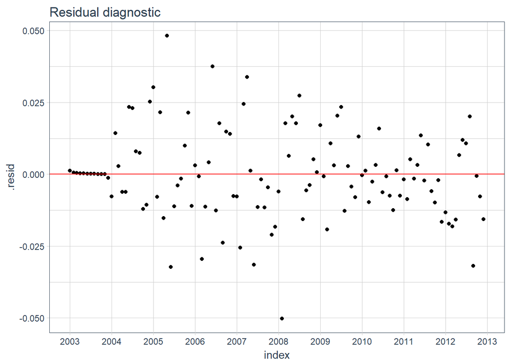

```r
# Plotting residuals to check whether any pattern is left
sw_augment(fit, timetk_idx = TRUE) %>%
  ggplot(aes(x = index, y = .resid)) +
  geom_point() +
  geom_hline(yintercept = 0, color = "red") +
  labs(title = "Residual diagnostic") +
  scale_x_date(date_breaks = "1 year", date_labels = "%Y") +
  theme_tq()
```

## Step 6: Investigate Test Error

```r
# Forecast next 24 months
fcast_arima <- forecast(fit, h = 24)

fcast_arima
```

```
##          Point Forecast    Lo 80    Hi 80    Lo 95    Hi 95
## Jan 2013       2.642789 2.621777 2.663801 2.610654 2.674924
## Feb 2013       2.644461 2.619367 2.669555 2.606083 2.682839
## Mar 2013       2.729609 2.701010 2.758209 2.685870 2.773348
## Apr 2013       2.758873 2.727153 2.790593 2.710362 2.807384
## May 2013       2.808556 2.773996 2.843115 2.755702 2.861409
## Jun 2013       2.802695 2.765512 2.839878 2.745829 2.859561
## Jul 2013       2.851479 2.811846 2.891112 2.790866 2.912092
## Aug 2013       2.855149 2.813209 2.897089 2.791007 2.919291
## Sep 2013       2.733270 2.689143 2.777397 2.665784 2.800756
## Oct 2013       2.676091 2.629881 2.722301 2.605418 2.746763
## Nov 2013       2.639883 2.591679 2.688086 2.566161 2.713604
## Dec 2013       2.705893 2.655775 2.756011 2.629244 2.782542
## Jan 2014       2.671823 2.616478 2.727167 2.587180 2.756465
## Feb 2014       2.673495 2.614616 2.732374 2.583448 2.763542
## Mar 2014       2.758643 2.696431 2.820855 2.663498 2.853788
## Apr 2014       2.787907 2.722531 2.853283 2.687923 2.887890
## May 2014       2.837589 2.769196 2.905983 2.732991 2.942188
## Jun 2014       2.831729 2.760445 2.903012 2.722710 2.940747
## Jul 2014       2.880512 2.806452 2.954573 2.767247 2.993778
## Aug 2014       2.884183 2.807446 2.960920 2.766823 3.001542
## Sep 2014       2.762304 2.682980 2.841628 2.640989 2.883619
## Oct 2014       2.705125 2.623296 2.786953 2.579979 2.830270
## Nov 2014       2.668916 2.584657 2.753175 2.540053 2.797779
## Dec 2014       2.734926 2.648305 2.821547 2.602451 2.867402
```

```r
# Reconvert the log10 value to normal
fcast_arima$mean<-10^(fcast_arima$mean)
fcast_arima$upper<-10^(fcast_arima$upper)
fcast_arima$lower<-10^(fcast_arima$lower)
fcast_arima$x<-10^(fcast_arima$x)

fcast_arima
```

```
##          Point Forecast    Lo 80    Hi 80    Lo 95     Hi 95
## Jan 2013       439.3281 418.5785 461.1062 407.9941  473.0685
## Feb 2013       441.0230 416.2623 467.2564 403.7226  481.7695
## Mar 2013       536.5490 502.3541 573.0714 485.1437  593.4010
## Apr 2013       573.9486 533.5233 617.4369 513.2891  641.7767
## May 2013       643.5105 594.2872 696.8109 569.7729  726.7909
## Jun 2013       634.8850 582.7904 691.6363 556.9665  723.7042
## Jul 2013       710.3604 648.4043 778.2364 617.8251  816.7552
## Aug 2013       716.3897 650.4430 789.0225 618.0271  830.4073
## Sep 2013       541.0908 488.8136 598.9589 463.2164  632.0572
## Oct 2013       474.3412 426.4623 527.5956 403.1052  558.1660
## Nov 2013       436.3978 390.5520 487.6253 368.2657  517.1348
## Dec 2013       508.0340 452.6628 570.1784 425.8376  606.0962
## Jan 2014       469.7022 413.5021 533.5406 386.5271  570.7754
## Feb 2014       471.5143 411.7334 539.9749 383.2195  580.1524
## Mar 2014       573.6447 497.0852 661.9957 460.7843  714.1481
## Apr 2014       613.6301 527.8746 713.3169 487.4419  772.4857
## May 2014       688.0014 587.7544 805.3463 540.7427  875.3625
## Jun 2014       678.7795 576.0305 799.8564 528.0930  872.4632
## Jul 2014       759.4730 640.4008 900.6848 585.1223  985.7757
## Aug 2014       765.9192 641.8680 913.9453 584.5524 1003.5579
## Sep 2014       578.5006 481.9257 694.4285 437.5106  764.9252
## Oct 2014       507.1361 420.0452 612.2842 380.1707  676.5041
## Nov 2014       466.5693 384.2884 566.4676 346.7795  627.7388
## Dec 2014       543.1583 444.9440 663.0518 400.3603  736.8887
```

```r
class(fcast_arima)
```

```
## [1] "forecast"
```

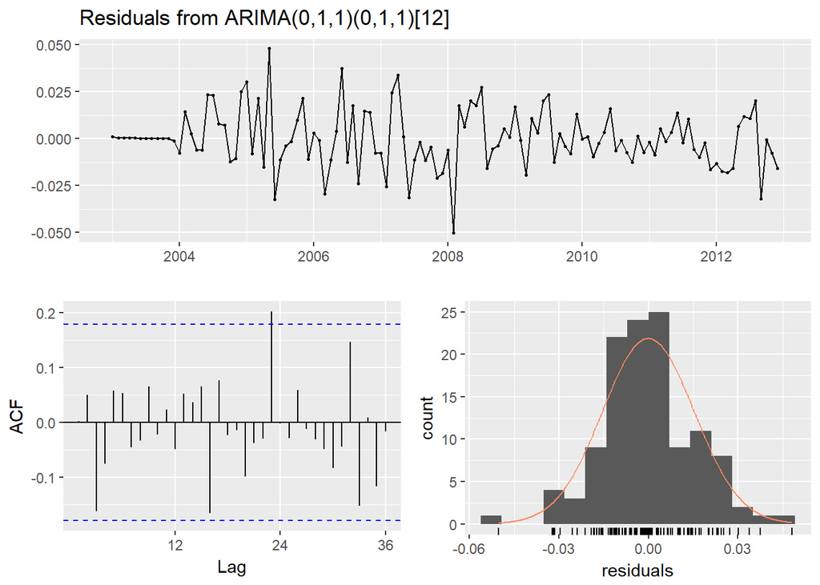

```
##
##  Ljung-Box test
##
## data:  Residuals from ARIMA(0,1,1)(0,1,1)[12]
## Q* = 20.416, df = 22, p-value = 0.557
##
## Model df: 2.   Total lags used: 24
```

```r
# Again checking residuals of forecast
checkresiduals(fcast_arima)
```

```r
# Check if object has timetk index
has_timetk_idx(fcast_arima)
```

```
## [1] TRUE
```

```r
# sw_sweep - tidies forecast output
fcast_tbl <- sw_sweep(fcast_arima, timetk_idx = TRUE)
head(fcast_tbl)
```

```
## # A tibble: 6 x 7
##   index      key    value lo.80 lo.95 hi.80 hi.95
##   <date>     <chr>  <dbl> <dbl> <dbl> <dbl> <dbl>
## 1 2003-01-01 actual   141    NA    NA    NA    NA
## 2 2003-02-01 actual   157    NA    NA    NA    NA
## 3 2003-03-01 actual   185    NA    NA    NA    NA
## 4 2003-04-01 actual   199    NA    NA    NA    NA
## 5 2003-05-01 actual   203    NA    NA    NA    NA
## 6 2003-06-01 actual   189    NA    NA    NA    NA
```

```r
tail(fcast_tbl)
```

```
## # A tibble: 6 x 7
##   index      key      value lo.80 lo.95 hi.80 hi.95
##   <date>     <chr>    <dbl> <dbl> <dbl> <dbl> <dbl>
## 1 2014-07-01 forecast   759   640   585   901   986
## 2 2014-08-01 forecast   766   642   585   914  1004
## 3 2014-09-01 forecast   579   482   438   694   765
## 4 2014-10-01 forecast   507   420   380   612   677
## 5 2014-11-01 forecast   467   384   347   566   628
## 6 2014-12-01 forecast   543   445   400   663   737
```

```r
# # Taking antilog of base 10
# fcast_tbl[,3:7] <- 10^fcast_tbl[,3:7]

actual_tbl <- Sales_Data[121:144,]
```

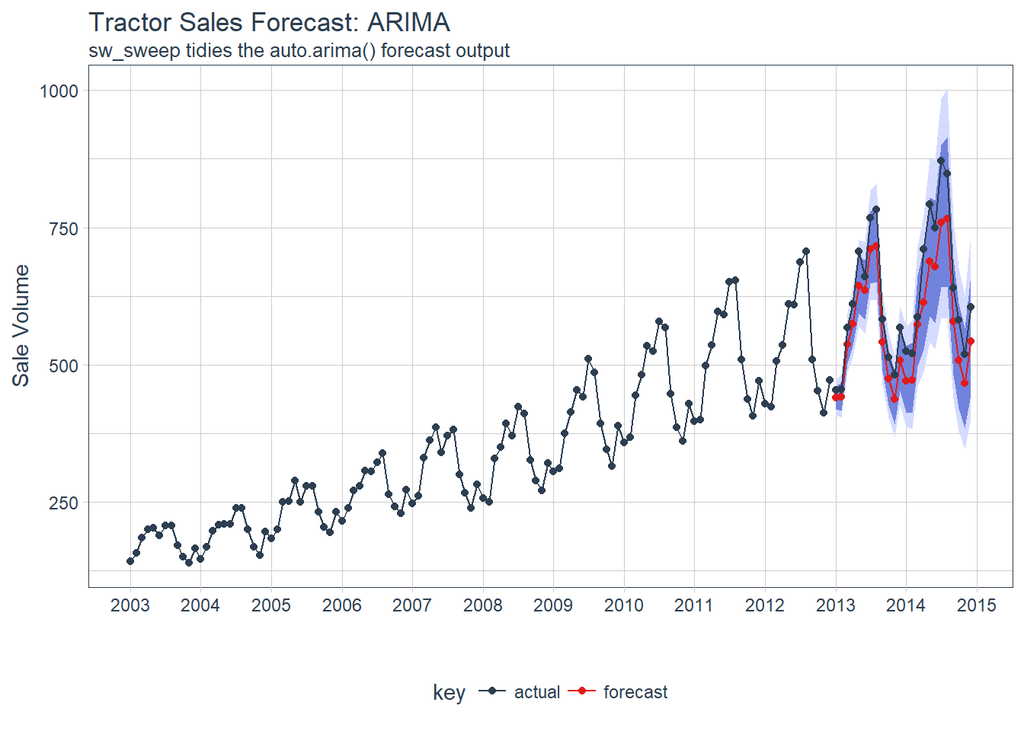

```r
# Visualize the forecast with ggplot
fcast_tbl %>%
  ggplot(aes(x = index, y = value, color = key)) +
  # 95% CI
  geom_ribbon(aes(ymin = lo.95, ymax = hi.95),
              fill = "#D5DBFF", color = NA, size = 0) +
  # 80% CI
  geom_ribbon(aes(ymin = lo.80, ymax = hi.80, fill = key),
              fill = "#596DD5", color = NA, size = 0, alpha = 0.8) +
  # Prediction
  geom_line() +
  geom_point() +
  # Actuals
  geom_line(aes(x = date, y = value), color = palette_light()[[1]], data = actual_tbl) +
  geom_point(aes(x = date, y = value), color = palette_light()[[1]], data = actual_tbl) +
  # Aesthetics
  labs(title = "Tractor Sales Forecast: ARIMA", x = "", y = "Sale Volume",
       subtitle = "sw_sweep tidies the auto.arima() forecast output") +
  scale_x_date(date_breaks = "1 year", date_labels = "%Y") +
  scale_color_tq() +
  scale_fill_tq() +
  theme_tq()
```

```r
# Investigate test error
error_tbl <- left_join(actual_tbl, fcast_tbl, by = c("date" = "index")) %>%
  rename(actual = value.x, pred = value.y) %>%
  select(date, actual, pred) %>%
  mutate(
    error     = actual - pred,
    error_pct = error / actual
  )
error_tbl
```

```
## # A tibble: 24 x 5
##    date       actual  pred error error_pct
##    <date>      <int> <dbl> <dbl>     <dbl>
##  1 2013-01-01    454   439  14.7    0.0323
##  2 2013-02-01    455   441  14.0    0.0307
##  3 2013-03-01    568   537  31.5    0.0554
##  4 2013-04-01    610   574  36.1    0.0591
##  5 2013-05-01    706   644  62.5    0.0885
##  6 2013-06-01    661   635  26.1    0.0395
##  7 2013-07-01    767   710  56.6    0.0738
##  8 2013-08-01    783   716  66.6    0.0851
##  9 2013-09-01    583   541  41.9    0.0719
## 10 2013-10-01    513   474  38.7    0.0754
## # ... with 14 more rows
```

```r
# Calculate test error metrics
test_residuals <- error_tbl$error
test_error_pct <- error_tbl$error_pct * 100 # Percentage error

me   <- mean(test_residuals, na.rm=TRUE)
rmse <- mean(test_residuals^2, na.rm=TRUE)^0.5
mae  <- mean(abs(test_residuals), na.rm=TRUE)
mape <- mean(abs(test_error_pct), na.rm=TRUE)
mpe  <- mean(test_error_pct, na.rm=TRUE)

tibble(me, rmse, mae, mape, mpe) %>% glimpse()
```

```
## Observations: 1
## Variables: 5
## $ me   <dbl> 55.17138
## $ rmse <dbl> 61.05511
## $ mae  <dbl> 55.17138
## $ mape <dbl> 8.512209
## $ mpe  <dbl> 8.512209
```

Alternatively, you can use accuracy() function to check accuracy of your forecast.

```r
# Check accuracy
round(accuracy(fcast_arima, Sales_Data_TS), 3)
```

```
##                   ME    RMSE     MAE    MPE   MAPE  MASE  ACF1 Theil's U
## Training set 339.334 365.363 339.334 99.166 99.166 8.547 0.927        NA
## Test set      55.171  61.055  55.171  8.512  8.512 1.390 0.418     0.685
```

## Step 7: Make Predictions

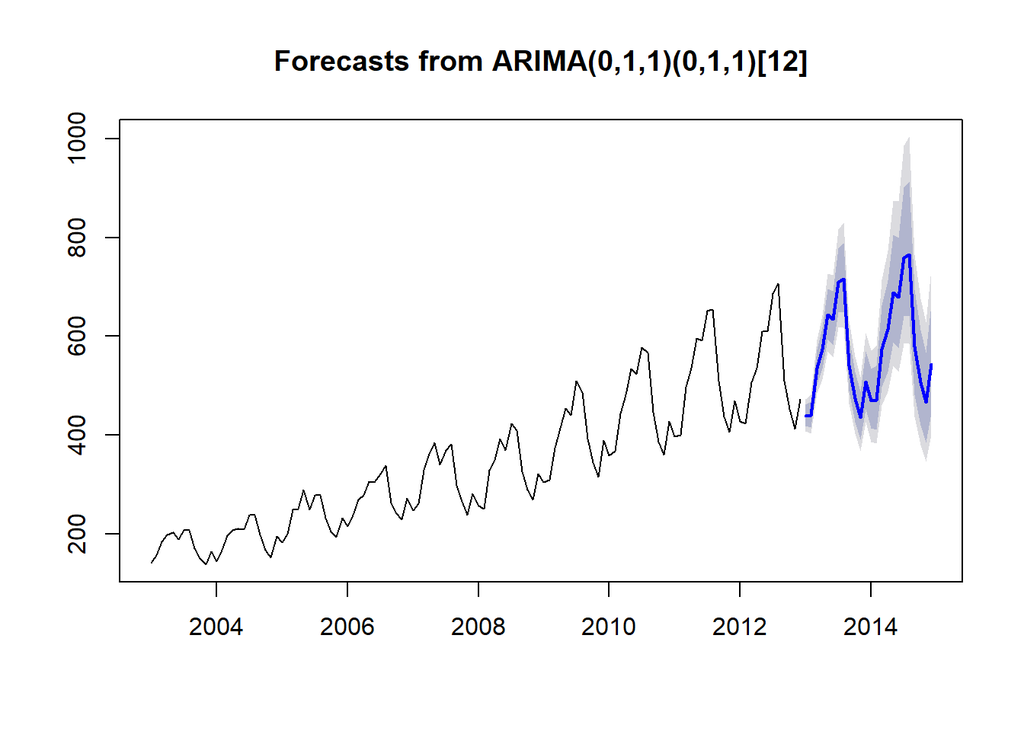

```r
plot(fcast_arima)
```

## Conclusion

I hope this will help you to deal with time series forecasting using ARIMA. It is great learning experience to while doing this analysis and I tried my best to bring togegher all the logic need to focus while dealing with forecasting problem. Also, I would like to thank some great people whose writings help me alot to understand the core concepts of forecasting: Rob J Hyndman and George Athanasopoulos, Kunal Jain, Roopam Upadhyay and Matt Dancho.

### References:

[Forecasting: Principles and Practice](http://otexts.org/fpp2/)  
[A Complete Tutorial on Time Series Modeling in R](https://www.analyticsvidhya.com/blog/2015/12/complete-tutorial-time-series-modeling/) [You CANalytics](http://ucanalytics.com/blogs/step-by-step-graphic-guide-to-forecasting-through-arima-modeling-in-r-manufacturing-case-study-example/)  
[Business-Science: TIDY FORECASTING WITH SWEEP](http://www.business-science.io/code-tools/2017/10/25/demo_week_sweep.html)